# Welcome to Preparatory Labs for Databases

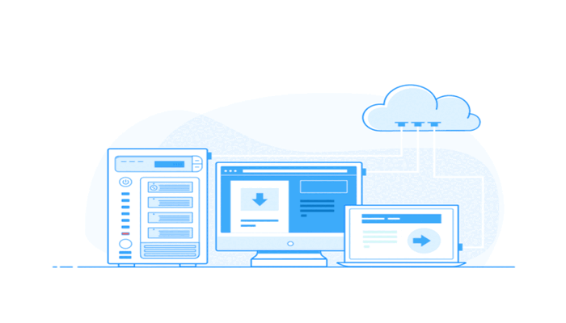

## 1 Course Overview

### 1.1 Course Description

This SQL Bootcamp is designed to teach students, particularly those in applied business analytics and data science, the foundations and advanced techniques of SQL using both **MySQL** and **PostgreSQL**. Over nine modules, you will master fundamental SQL concepts such as querying data, working with joins, stored procedures, transactions, and more. Each module is accompanied by self-guided learning tasks, quizzes, and practical assessments to ensure a deep understanding of database concepts.

### 1.2 Learning Outcomes

Upon completing the SQL Bootcamp, you will be able to:

- Understand and write basic SQL queries.
- Retrieve, manipulate, and manage data efficiently.
- Work with multiple tables using joins and set operations.
- Create and manage databases, tables, and indexes.
- Understand and implement stored procedures, functions, triggers, and transactions.

## 2 SQL Course Outline

### 2.1 Getting Started with SQL

- **Objectives**:
  - Introduction to relational databases, setting up MySQL and PostgreSQL, understanding SQL syntax and data types.
- **Lectures**:
  1. **Introduction to MySQL and PostgreSQL**: Overview of popular relational databases and setting up local environments.
  2. **Data Types**: Understanding core SQL data types (e.g., `int`, `varchar`, `date`, etc.).
  3. **Creating Databases and Tables**: Steps to create a new database and define tables.
  4. **Inserting, Updating, and Deleting Records**: Basic SQL operations for manipulating records.

### 2.2 Retrieving Data with SQL

- **Objectives**:
  - Learn to write SQL queries to retrieve data from a database.
- **Lectures**:
  1. **SELECT Statements**: Introduction to the `SELECT` statement for querying data.
  2. **WHERE Clauses and Filtering Data**: Using `WHERE` to filter query results based on conditions.
  3. **Sorting Data with ORDER BY, LIMIT, and OFFSET**: Techniques for ordering and limiting results.
  4. **Using Variables in Queries**: Working with variables to enhance query flexibility.

### 2.3 Modifying Data with SQL

- **Objectives**:
  - Master techniques for modifying data in SQL databases.
- **Lectures**:
  1. **INSERT, UPDATE, DELETE Statements**: Essential commands for data manipulation.
  2. **Error Handling and Constraints**: Handling constraints like `PRIMARY KEY` and `FOREIGN KEY`, and error management.
  3. **Managing NULL Values and Default Values**: Handling missing or default values in SQL.
  4. **String Operations in SQL**: Useful string functions like `CONCAT`, `SUBSTRING`, etc.

### 2.4 Joins and Advanced Queries

- **Objectives**:
  - Learn to retrieve and work with data across multiple tables using SQL joins.
- **Lectures**:
  1. **INNER JOIN, LEFT JOIN, RIGHT JOIN, FULL JOIN**: Understanding different types of joins and their uses.
  2. **UNION and UNION ALL**: Combining results from multiple queries.
  3. **Grouping and Aggregating Data with GROUP BY**: Techniques for grouping data and using aggregate functions like `SUM`, `COUNT`, etc.
  4. **HAVING Clauses**: Filtering aggregated data with `HAVING`.

### 2.5 Managing Database Structures

- **Objectives**:
  - Learn to modify and optimize database structures for improved performance.
- **Lectures**:
  1. **ALTER TABLE and MODIFY Operations**: Altering table structures and modifying columns.
  2. **Creating and Deleting Indexes**: Indexing strategies for faster data retrieval.
  3. **Optimizing Queries for Performance**: Techniques to improve query execution times.
  4. **Handling Large Datasets and Backups**: Managing large datasets, backups, and recovery

### 2.6 Stored Procedures and Triggers

- **Objectives**:
  - Introduction to automation and server-side programming with stored procedures and triggers.e
- **Lectures**:
  1. **Creating and Calling Stored Procedures**: Writing reusable procedures for SQL operations.
  2. **Creating and Managing Triggers**: Automating actions with database triggers.
  3. **Error Handling in Stored Procedures**: Managing errors within stored procedures.
  4. **Performance Considerations**: Best practices for efficient stored procedures and triggers.